# Example Linear Regression

LR with R software

# 1 Introduction

Linear regression is computed in R using:

- the R function `lm` (for linear model)
- math formula explicitly implemented in R software.

We show that we get the same results.

We simulate below data $\lbrace x_i, y_i\rbrace_{i=1,\cdots,n}$ such that $\forall i$
$$y_i=a+b\ x_i+ \epsilon_i$$
where $\epsilon_i\sim \mathcal{N}(0,3^2)$ (Normal error) and $x_i\sim\mathcal{U}([0,100])$ (uniformally distributed in the range 0 to 100). The ground truth values for the parameters are chosen $a=2$ and $b=1$.

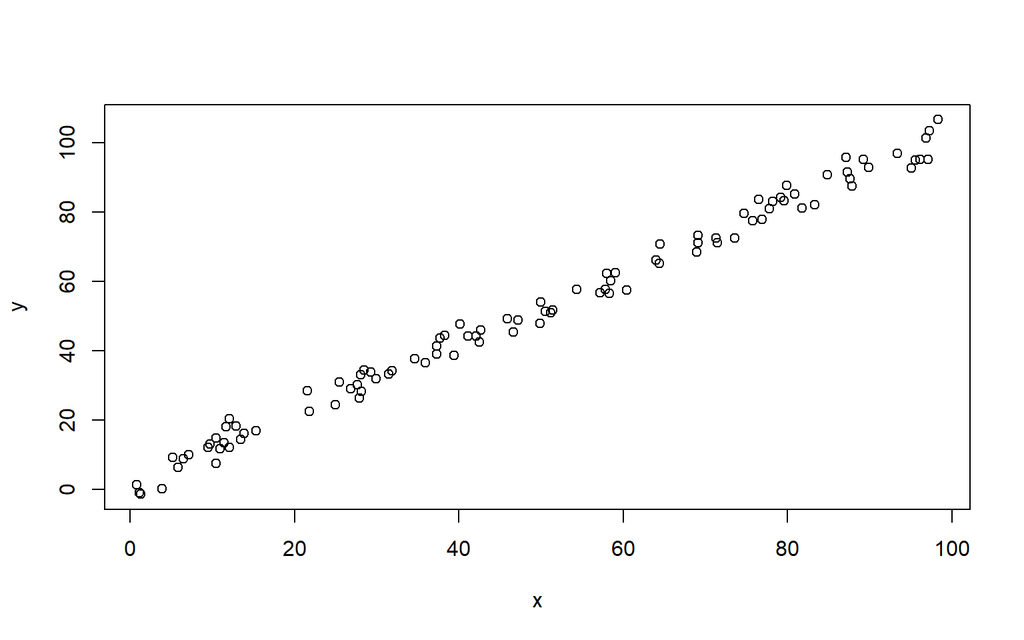

```r
n=100
error=rnorm(n,mean=0,sd=3) # gaussian noise
x=runif(n, min = 0, max = 100) # explanatory variable
a=2 # intercept (true value)
b=1 # slope (true value)
y=a+b*x+error
plot(x,y)
```

# 2 Linear Regression using R function *lm*

The code below aims are computing an estimate for $a$ and $b$ using the function *lm* in R.

```r
Linearfit<-lm(y~x)
summary(Linearfit)
```

```
##
## Call:
## lm(formula = y ~ x)
##
## Residuals:
##    Min     1Q Median     3Q    Max
## -5.612 -2.142  0.080  1.913  6.512
##
## Coefficients:
##             Estimate Std. Error t value Pr(>|t|)
## (Intercept) 1.814569   0.556440   3.261  0.00153 **
## x           1.010187   0.009805 103.029  < 2e-16 ***
## ---
## Signif. codes:  0 '***' 0.001 '**' 0.01 '*' 0.05 '.' 0.1 ' ' 1
##
## Residual standard error: 2.895 on 98 degrees of freedom
## Multiple R-squared:  0.9909, Adjusted R-squared:  0.9908
## F-statistic: 1.061e+04 on 1 and 98 DF,  p-value: < 2.2e-16
```

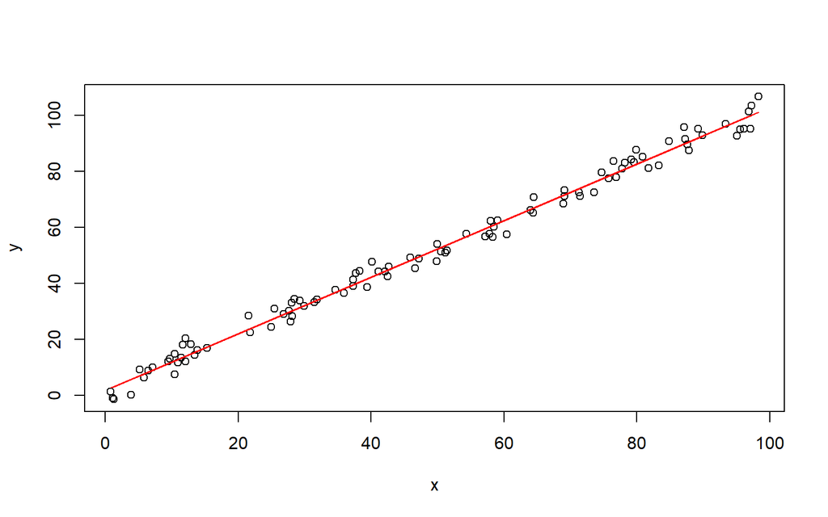

```r
plot(x,y)
lines(x,Linearfit$fitted.values,col = "red")
```

**Exercise:** What is the effect on increasing the value $n$ on the estimates of parameters $a$ and $b$ and their Standard Error reported?

# 3 Linear Regression using Algebra in R

Least squares estimates of the parameters $a$ and $b$ are computed by creating the matrix $\mathrm{X}$ with its first column full with 1s and its second column filled with the values of the explanatory variable $x$.
$$\hat{\beta}=(\mathrm{X}^T\mathrm{X})^{-1} \mathrm{X}^T \mathbf{y}$$
where $\mathbf{y}$ is the vector collecting the values of the response variable $y$. The estimated vector ofparameters is $\hat{\beta}=(\hat{a}\ \hat{b} )^T$.

```r
X=matrix(1,n,2)
X[,1]=rep(1, n)
X[,2]=x


# least square estimate
BetaHat=solve(t(X)%*%X)%*%t(X)%*%y
BetaHat
```

```
##          [,1]
## [1,] 1.814569
## [2,] 1.010187
```

Note that these estimates are the same as the ones found by the R function *lm* for parameters $a$ and $b$.

The standard deviation of the errors $\epsilon$ can also be computed:

```r
fitted =X %*% BetaHat
residuals=y-fitted
SSE=t(residuals)%*%residuals
sigmahatsq=SSE/(n-length(BetaHat))
#Residual standard error
sqrt(sigmahatsq)
```

```
##          [,1]
## [1,] 2.895173
```

The standard errors reported by *lm* for $\hat{\beta}=(\hat{a},\hat{b})^T$ can also be computed mathematically with
$$\mathbb{C}\lbrack \hat{\beta}\rbrack =\sigma^2 \
(\mathrm{X}^{T}\mathrm{X})^{-1}$$
see [my notes online](https://roznn.github.io/GLM/multiple-regression.html#covariance-of-hatbeta) for the derivation of this formula.

```r
# uncertainty of BetaHat (standard error)
CovBetaHat=solve(t(X)%*%X)*as.numeric(sigmahatsq)
Std.Error.BetaHat=sqrt(diag(CovBetaHat))
Std.Error.BetaHat
```

```
## [1] 0.55644024 0.00980488
```

Other statistics computed by *lm*:

```r
#Multiple R-squared: (coefficient of determination)
S0=sum((y-mean(y))*(y-mean(y)))
Rsq=(S0-SSE)/S0
Rsq
```

```
##           [,1]
## [1,] 0.9908522
```